# Time Series Analysis

## Lake Street & Knox Ave S

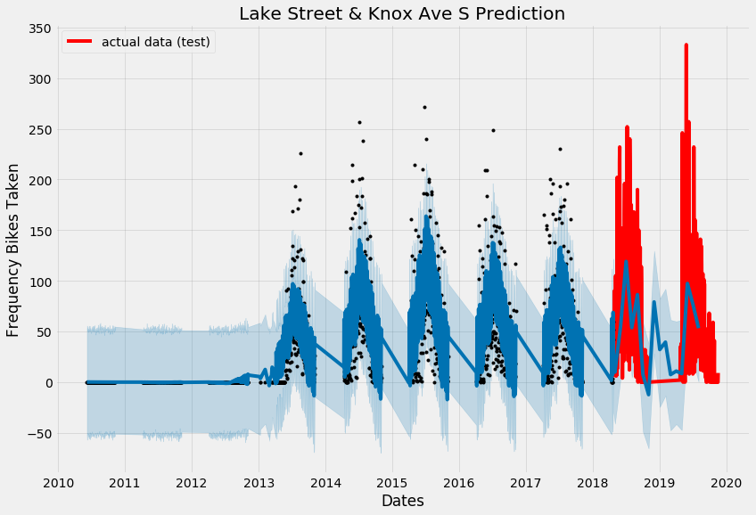

```python
#------ Graph actual data vs forecasts data with confidence intervals ------
fig, ax = plt.subplots(figsize=(12, 8))
ax.plot(df_T3_test.set_index('Date'), color= 'red', label='actual data (test)')
fig= my_model_T3.plot(forecast_T3, uncertainty=True, ax=ax)

ax.set_title('Lake Street & Knox Ave S Prediction')
ax.set_xlabel('Dates')
ax.set_ylabel('Frequency Bikes Taken')

ax.legend()
```

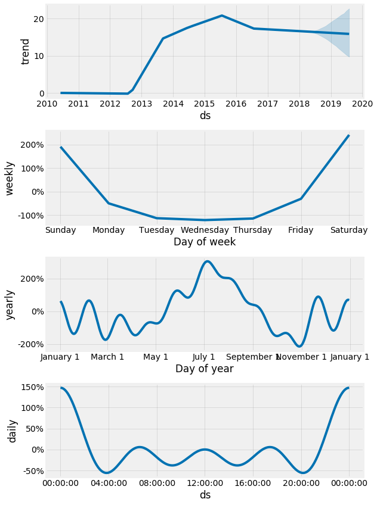

```python
fig2 = my_model_T3.plot_components(forecast_T3)
```

## YWCA Downtown

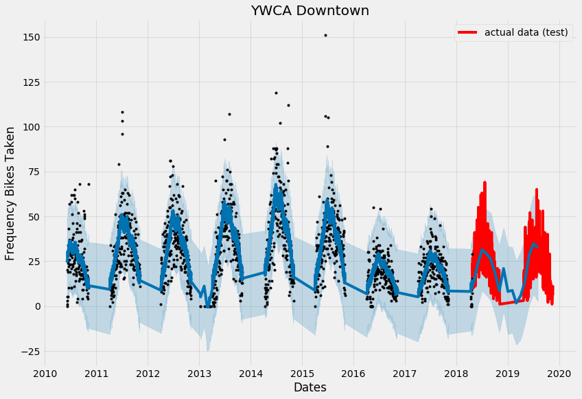

```python
#------ Graph actual data vs forecasts data with confidence intervals ------
fig, ax = plt.subplots(figsize=(12, 8))
ax.plot(df_T4_test.set_index('Date'), color= 'red', label='actual data (test)')
fig= my_model_T4.plot(forecast_T4, uncertainty=True, ax=ax)

ax.set_title('YWCA Downtown')
ax.set_xlabel('Dates')
ax.set_ylabel('Frequency Bikes Taken')

ax.legend()
```

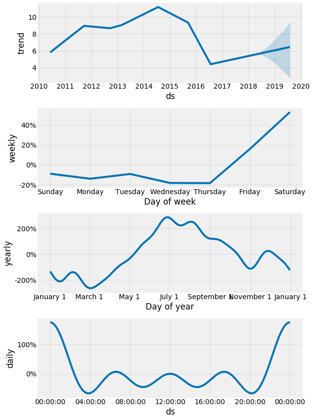

```python
fig2 = my_model_T4.plot_components(forecast_T4)
```

## Question 3 Conclusion

Let us review the question:

*What stations are the most frequent starting points for trips? Should we add more bikes at the frequent starting point or should we remove bikes in at the frequent starting point?*

We have created the trends for all four locations: IDS Center, 100 Main Street SE, Lake Street & Knox Ave S, YWCA Downtown.

**IDS Center**: The IDS nice ride station is most popular during the weekdays due to the location in downtown and is in use yearly from around May - November. The trend has been going downwards since 2015. We can see that in 2019 the number of rides started at this location is at 0. The reason being that NiceRide removed this location at the beginning of 2019. But why would they remove their most popular station? Obviously, it has been showing a decreaseing trend since 2015. I am going to guess the removal is due to the electic scooters which came to downtown Minneapolis in 2018. Which is around the time that dockless bikes also started.

**100 Main Street SE**: The 100 Main Street SE station is most popular on the weekends from May to November. Since around 2016 the trend has been pointed downwards. The location is between downtown and the University of Minnesota next to the Stone Arch Bridge. The nice ride station is still available but I am going to guess the decreasing trend is again due to the start of electric scooters and dockless bikes.

**Lake Street & Knox Ave S**: The station is most popular on weekends from April to October. The location is near Bde Maka Ska. The trend is decreasing but is still relatively high. Still averaging around 30 rides a day during the 2020 season. The success of this location is due to the close proximity to the lakes. Dockless may not be the best implementation of NiceRide near the lake since they can be placed in any location and may be hard to find for family and friend rides around the lake. Electric scooters are usually kept closer to downtown and uptown area.

# Conclusion

Now we are able to answer our question:

*1.) What is the overall bike usage for each year and the predicted usage for future years?*

We will used our FB Prophet to answer this question:

- For each year, the services is only popular during April to October. This is understandable as Winter in Minnesota can affect the usage of biker.
- If not account for current COVID-19, Nice Ride Minnesota still decreases in riderships (from 2018 to 2019), the real data shows that riderships has already decreased
- In the near future, this services will not be in high demand, Unless there is a change in technology or company vision, this service might be failing to achieve its goals.

*2.) What is the typical duration of the trip? Should we change how we charge people, either per trip or by duration?*

As we can see, if Nice Ride were to charge by trip duration, they would not generate any revenue. So, *THEY SHOULD ALWAYS CHARGE PEOPLE PER TRIPS*.

Nice Ride should keep how they currently charge people:

- Single Ride
- Day Pass
- Annual Membership

*3.) Should we add more bikes to any of these locations?*

With the trends found at each of these four locations from FB Prophet it suggests

- We should not add more bikes and maybe even shift more into dockless bikes or electric bikes in the downtown areas.
- The station close to Bde Maka Ska is a different situation. The data suggests that the station is doing well with around 30 rides a day during the season.

More research needs to be done to implement more dockless bikes in the area.

## Resources:

1. https://otexts.com/fpp2/tspatterns.html
2. https://robjhyndman.com/papers/forecastingoverview.pdf
3. https://faculty.wharton.upenn.edu/wp-content/uploads/2016/10/Simple-versus-complex-forcasting-The-evidence_1.pdf
4. https://hbr.org/1971/07/how-to-choose-the-right-forecasting-technique